# Hands-on Exercise 7: Visualising and Analysing Time-oriented Data

Author

Andy Tai

Published

June 11, 2026

Modified

June 11, 2026

## 1 Overview

This exercise aims to plot the following data visualisations with R:

- calender heatmap by using ggplot2 functions,
- cycle plot by using ggplot2 function,
- slopegraph
- horizon chart

## 2 Getting Started

For this exercise, the scales, viridis, lubridate, ggthemes, gridExtra, readxl, knitr, data.table and tidyverse packages will be used.

```r
pacman::p_load(scales, viridis, lubridate,
               ggthemes, gridExtra, readxl,
               knitr, data.table,
               CGPfunctions, ggHoriPlot,
               tidyverse, ggHoriPlot)
```

## 3 Plotting Calendar Heatmap

Objectives for this section:

- plot a calender heatmap by using ggplot2 functions and extension,
- to write function using R programming,
- to derive specific date and time related field by using base R and lubridate packages
- to perform data preparation task by using tidyr and dplyr packages.

**Step 1: The data**

For the purpose of this hands-on exercise, `eventlog.csv` file will be used. This data file consists of 199,999 rows of time-series cyber attack records by country.

The code chunk below is used to import `eventlog.csv` file into R as a data frame attacks.

```r
attacks <- read_csv("data/eventlog.csv")
```

**Step 2: Examining the data structure**

kable() can be used to review the structure of the imported data frame.

```r
kable(head(attacks))
```

| timestamp | source_country | tz |
| --- | --- | --- |
| 2015-03-12 15:59:16 | CN | Asia/Shanghai |
| 2015-03-12 16:00:48 | FR | Europe/Paris |
| 2015-03-12 16:02:26 | CN | Asia/Shanghai |
| 2015-03-12 16:02:38 | US | America/Chicago |
| 2015-03-12 16:03:22 | CN | Asia/Shanghai |
| 2015-03-12 16:03:45 | CN | Asia/Shanghai |

There are three columns, namely `timestamp`, `source_country` and `tz`.

- `timestamp` field stores date-time values in POSIXct format.
- `source_country` field stores the source of the attack. It is in ISO 3166-1 alpha-2 country code.
- `tz` field stores time zone of the source IP address.

**Step 3: Data preparation**

**(a) Deriving weekday and hour of day fields**

Before we can plot the calender heatmap, two new fields namely wkday and hour need to be derived. In this step, we will write a function to perform the task.

```r
make_hr_wkday <- function (ts, sc, tz) {
    # convert each time with the appropriate timezone,
    # the timezone parameter, tz, only takes a single value,
    # then extract its weekdays and hour
  real_times <- ymd_hms(ts,
                        tz = tz[1],     #<< for group by tz later, simply use the first tz value of groupby
                        quiet = TRUE)

  dt <- data.table(source_country = sc,
                   wkday= weekdays(real_times),
                   hour = hour(real_times))
  return (dt)
}
```

- `ymd_hms()` and `hour()` are from [lubridate](https://lubridate.tidyverse.org/) package, and
- `weekdays()` is a base R function.

**(b) Deriving the attacks tibble data frame**

```r
# convert weekday and hour into factor so they'll be ordered when plotting
wkday_levels <- c('Saturday', 'Friday',
                  'Thursday', 'Wednesday',
                  'Tuesday', 'Monday',
                  'Sunday')

attacks <- attacks %>%
  group_by(tz) %>%
  do(make_hr_wkday(.$timestamp,
                   .$source_country,
                   .$tz)) %>%
  ungroup() %>%
  mutate(wkday = factor(wkday, levels = wkday_levels),
         hour = factor(hour, levels = 0:23))  #<< 24 hrs
```

- By grouping the `attacks` dataframe by the `tz` column and applying the `make_hr_wkday` function within each group, the resulting dataframe will contain the source country, weekday, and hour columns based on the timestamp, source country, and time zone information, grouped by the unique time zones in the `tz` column of the `attacks` dataframe.
- Beside extracting the necessary data into attacks data frame, `mutate()` of dplyr package is used to convert wkday and hour fields into factor so they’ll be ordered when plotting.

Table below shows the tidy tibble table after processing.

```r
kable(head(attacks))
```

| tz | source_country | wkday | hour |
| --- | --- | --- | --- |
| Africa/Cairo | BG | Saturday | 20 |
| Africa/Cairo | TW | Sunday | 6 |
| Africa/Cairo | TW | Sunday | 8 |
| Africa/Cairo | CN | Sunday | 11 |
| Africa/Cairo | US | Sunday | 15 |
| Africa/Cairo | CA | Monday | 11 |

**Step 4: Building the calendar heatmaps**

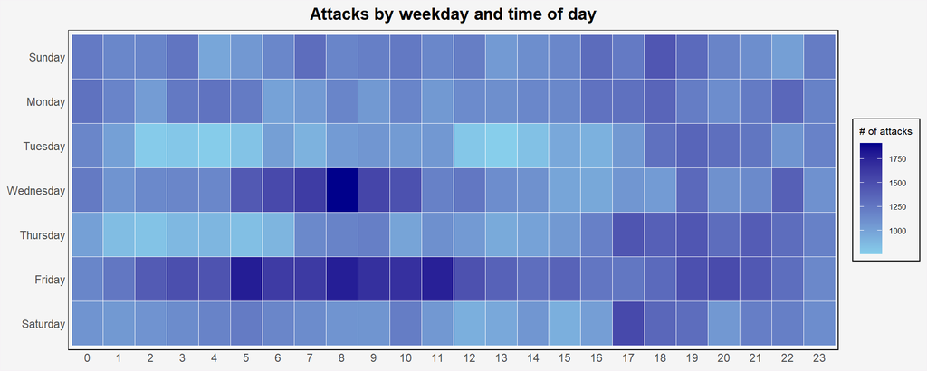

```r
grouped <- attacks %>%
  count(wkday, hour) %>%
  ungroup() %>%
  na.omit()

ggplot(grouped,
       aes(hour,
           wkday,
           fill = n)) +
  geom_tile(color = 'white',
            size = 0.1) +
  theme_tufte(base_family = 'sans') +
  scale_fill_gradient(name = "# of attacks",
                      low = "sky blue",
                      high = "dark blue") +
  labs(x = NULL,
       y = NULL,
       title = "Attacks by weekday and time of day") +
  theme(axis.ticks = element_blank(),
        plot.title = element_text(hjust = 0.5, face = "bold"),
        axis.title.x = element_blank(),
        axis.title.y = element_text(hjust = 1, angle = 0),
        legend.title = element_text(size = 8),
        legend.text = element_text(size = 6),
        plot.background = element_rect(fill = "#f5f5f5", color = "#f5f2f5"),
        legend.background = element_rect(fill = "#f5f5f5"),
        panel.background = element_rect(fill = "#f5f5f5"))
```

**Step 5: Building multiple calendar heatmaps**

To plot the calendar heatmaps for the top 4 countries, we first derive the `attacks_by_country` tibble by counting and ranking attacks per country, then extract the top 4 country names using `top_n()`. The `top4_attacks` data frame is then created by filtering the `attacks` data frame using the `top4` vector, aggregating by `source_country`, `wkday`, and `hour`. Notably, `source_country` is converted into a factor ordered by attack count, which ensures the facets are displayed in the correct order.

The chart below uses `facet_wrap()` to plot a separate calendar heatmap for each of the top 4 countries side by side, allowing easy comparison of attack patterns across countries by weekday and time of day.

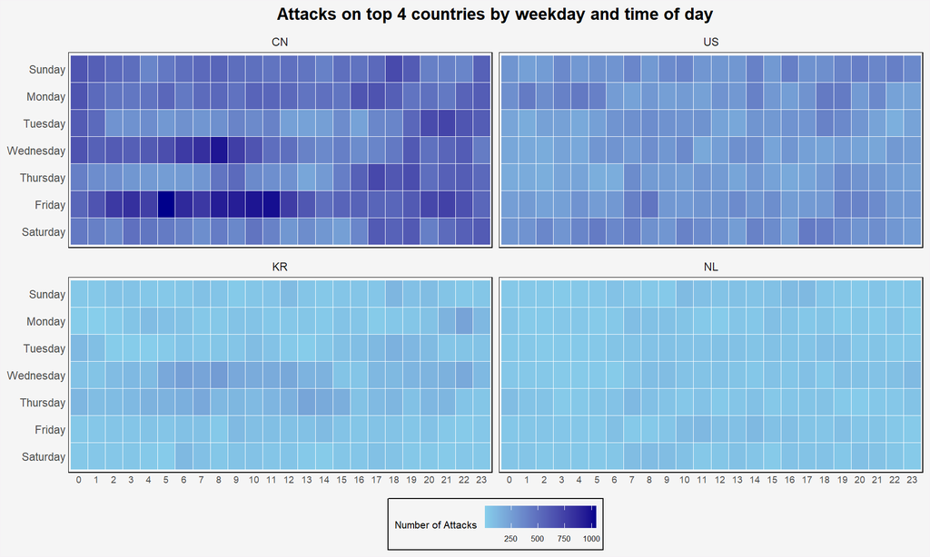

```r
attacks_by_country <- count(attacks, source_country) %>%
  mutate(percent = percent(n / sum(n))) %>%
  arrange(desc(n))

top4 <- attacks_by_country %>%
  top_n(4, wt = n) %>%
  pull(source_country)

attacks %>%
  filter(source_country %in% top4) %>%
  count(source_country, wkday, hour) %>%
  ungroup() %>%
  mutate(source_country = factor(source_country, levels = top4)) %>%
  na.omit() %>%
  ggplot(aes(hour, wkday, fill = n)) +
  geom_tile(color = "white", size = 0.1) +
  theme_tufte(base_family = "sans") +
  scale_fill_gradient(name = "Number of Attacks",
                      low = "sky blue",
                      high = "dark blue") +
  facet_wrap(~source_country, ncol = 2) +
  labs(x = NULL, y = NULL,
       title = "Attacks on top 4 countries by weekday and time of day") +
  theme(axis.ticks = element_blank(),
        axis.text.x = element_text(size = 7),
        plot.title = element_text(hjust = 0.5, face = "bold"),
        legend.title = element_text(size = 8),
        legend.text = element_text(size = 6),
        legend.position = "bottom",
        plot.background = element_rect(fill = "#f5f5f5", color = "#f5f2f5"),
        legend.background = element_rect(fill = "#f5f5f5"),
        panel.background = element_rect(fill = "#f5f5f5"),
        panel.border = element_blank())
```

## 4 Plotting Cycle Plot

In this section, we learn how to plot a cycle plot showing the time-series patterns and trend of visitor arrivals from Vietnam programmatically by using ggplot2 functions.

**Step 1: data import**

The dataset `arrivals_by_air.xlsx` will be used. The code chunk below imports `arrivals_by_air.xlsx` by using `read_excel()` of readxl package and save it as a tibble data frame called air.

```r
air <- read_excel("data/arrivals_by_air.xlsx")

air %>%
  head(5) %>%
  kable()
```

| Month-Year | Republic of South Africa | Canada | USA | Bangladesh | Brunei | China | Hong Kong SAR (China) | India | Indonesia | Japan | South Korea | Kuwait | Malaysia | Myanmar | Pakistan | Philippines | Saudi Arabia | Sri Lanka | Taiwan | Thailand | United Arab Emirates | Vietnam | Belgium & Luxembourg | CIS | Finland | France | Germany | Ireland | Italy | … |
| --- | --- | --- | --- | --- | --- | --- | --- | --- | --- | --- | --- | --- | --- | --- | --- | --- | --- | --- | --- | --- | --- | --- | --- | --- | --- | --- | --- | --- | --- | --- |
| 2000-01-01 | 3291 | 5545 | 25906 | 2883 | 3749 | 33895 | 13692 | 19235 | 65151 | 59288 | 21457 | 507 | 27472 | 1177 | 2150 | 8404 | 1312 | 3922 | 15766 | 12048 | 1318 | 1527 | 1434 | 2703 | 1634 | 4752 | 12739 | 1292 | 3544 | … |
| 2000-02-01 | 2357 | 6120 | 28262 | 2469 | 3236 | 34344 | 19870 | 18975 | 37105 | 58188 | 19634 | 199 | 29084 | 1161 | 2496 | 9128 | 623 | 3988 | 24861 | 12745 | 899 | 2269 | 1596 | 1182 | 1297 | 6391 | 13093 | 1200 | 2897 | … |
| 2000-03-01 | 4036 | 6255 | 30439 | 2904 | 3342 | 27053 | 17086 | 21049 | 44205 | 74426 | 20719 | 386 | 30504 | 1355 | 2429 | 11691 | 1578 | 4259 | 18767 | 16971 | 1474 | 2034 | 1548 | 1088 | 1220 | 5528 | 13645 | 1368 | 2717 | … |
| 2000-04-01 | 4241 | 4521 | 25378 | 2843 | 5117 | 30464 | 22346 | 26160 | 45480 | 49985 | 17489 | 221 | 34478 | 1593 | 2711 | 14141 | 705 | 6579 | 22735 | 20397 | 1284 | 2420 | 1592 | 1012 | 1208 | 5544 | 13366 | 1345 | 2512 | … |
| 2000-05-01 | 2841 | 3914 | 26163 | 2793 | 4152 | 30775 | 16357 | 35869 | 38350 | 48937 | 19398 | 164 | 34795 | 1397 | 2594 | 13305 | 679 | 4625 | 18399 | 15769 | 1042 | 1833 | 1167 | 660 | 743 | 4225 | 10878 | 1067 | 2205 | … |

```r
class(air$`Month-Year`)
```

```
[1] "POSIXct" "POSIXt"
```

Note that Month-year column is detected as date-time format in R.

**Step 2: extract date**

Next, two new fields called month and year are derived from Month-Year field.

```r
air$month <- factor(month(air$`Month-Year`),  # extract month
                    levels = 1:12,  #<< 12 months
                    ordered= TRUE)

air$year <- year(ymd(air$`Month-Year`))   # extract year
```

**Step 3: extract country**

Next, the code chunk below is use to create dataframe containing the arrival data for Vietnam from 2010 onwards by selecting columns ‘Vietnam’, ’ month’ and ‘year’ from the air dataframe.

```r
Vietnam <- air %>%
  select(`Vietnam`,
         month,
         year) %>%
  filter(year >= 2010)
```

**Step 4: average arrivals**

The code chunk below uses group_by() and summarise() of dplyr to compute year average arrivals by month for all the years in Vietnam dataframe.

```r
hline.data <- Vietnam %>%
  group_by(month) %>%
  summarise(avgvalue = mean(`Vietnam`))
```

**Step 5: cycle plot**

The code chunk below is used to plot the cycle plot.

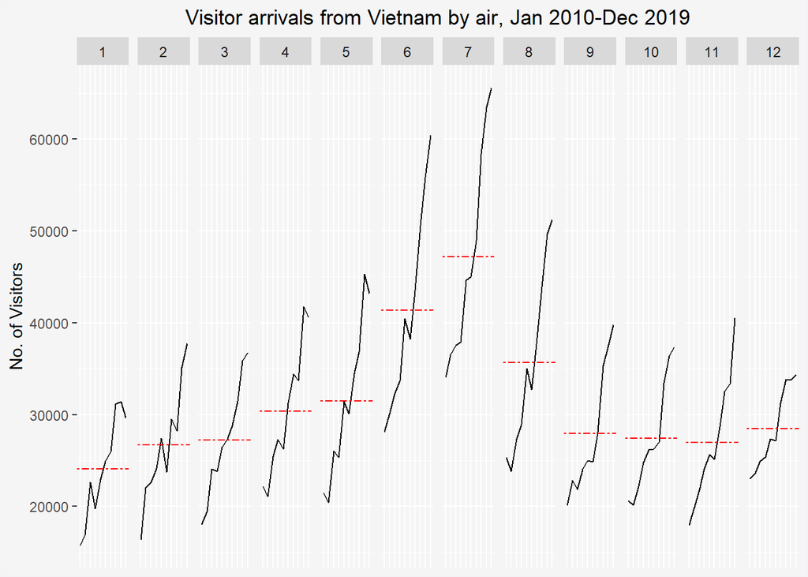

```r
ggplot() +
  geom_line(data=Vietnam,
            aes(x=factor(year),
                y=`Vietnam`,
                group=month),
            colour="black") +
  geom_hline(aes(yintercept=avgvalue),  #<< geom_hline does not require group=month for facet?
             data=hline.data,
             linetype=6,
             colour="red",
             size=0.5) +
  facet_grid(~month) +
  labs(axis.text.x = element_blank(),
       title = "Visitor arrivals from Vietnam by air, Jan 2010-Dec 2019") +
  ylab("No. of Visitors") +
  theme(axis.text.x = element_blank(),
        axis.ticks.x = element_blank(),
        axis.title.x = element_blank(),
    plot.title = element_text(hjust = 0.5),
        legend.title = element_text(size = 8),
        legend.text = element_text(size = 6),
        plot.background = element_rect(fill = "#f5f5f5", color = "#f5f2f5"),
        legend.background = element_rect(fill="#f5f5f5"),
        panel.background = element_rect(fill="#f5f5f5")
      )
```

## 5 Plotting Slopegraph

In this section, we learn how to plot a slopegraph with R.

Ensure CGPfunctions is installed and loaded in R. For more reference materials, refer to Using newggslopegraph and [newggslopegraph()](https://www.rdocumentation.org/packages/CGPfunctions/versions/0.6.3/topics/newggslopegraph).

**Step 1: data import**

Import the rice data set into R environment by using the code chunk below.

```r
rice <- read_csv("data/rice.csv")

class('year')
```

```
[1] "character"
```

**Step 2: Plotting slopegraph**

Next, code chunk below will be used to plot a basic slopegraph as shown below.

The slopegraph below compares rice yield across the top 11 Asian countries between 1961 and 1980, using newggslopegraph() from the CGPfunctions package. Each line represents a country, making it easy to see which countries improved, declined, or maintained their yield over the two decades.

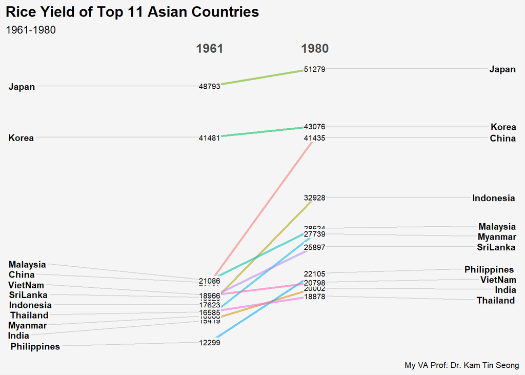

```r
rice %>%
  mutate(Year = factor(Year)) %>%
  filter(Year %in% c(1961, 1980)) %>%
  newggslopegraph(Times = Year,
                  Measurement = Yield,
                  Grouping = Country,
                Title = "Rice Yield of Top 11 Asian Countries",
                SubTitle = "1961-1980",
                Caption = "My VA Prof: Dr. Kam Tin Seong",
                DataLabelFillColor = "#f5f5f5",) +
    theme(
        plot.background = element_rect(fill = "#f5f5f5", color = "#f5f2f5"),
        panel.background = element_rect(fill="#f5f5f5")
      )
```

**Optional: Highlighting a country**

**(a) LineColor**

LineColor is simply a character vector that you can fill any way you choose.

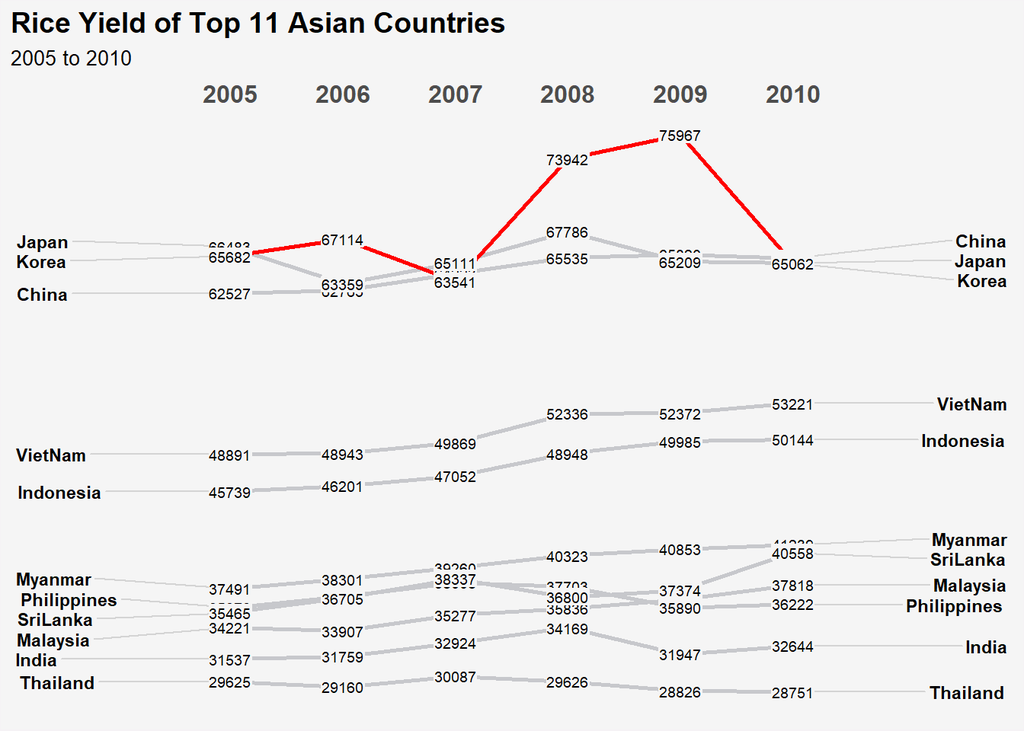

```r
rice %>%
  mutate(Year = factor(Year)) %>%
  filter(Year %in% c(2005, 2006, 2007, 2008, 2009, 2010)) %>%
  newggslopegraph(Year, Yield, Country,
                Title = "Rice Yield of Top 11 Asian Countries",
                SubTitle = "2005 to 2010",
                Caption = NULL,
                LineColor = c("#c7c8cc", "#c7c8cc", "#c7c8cc", "#c7c8cc","red","#c7c8cc","#c7c8cc","#c7c8cc","#c7c8cc","#c7c8cc"),
                DataLabelFillColor = "#f5f5f5",) +
    theme(
        plot.background = element_rect(fill = "#f5f5f5", color = "#f5f2f5"),
        panel.background = element_rect(fill="#f5f5f5")
      )
```

**(b) by country**

Assigning by country name is much clearer!

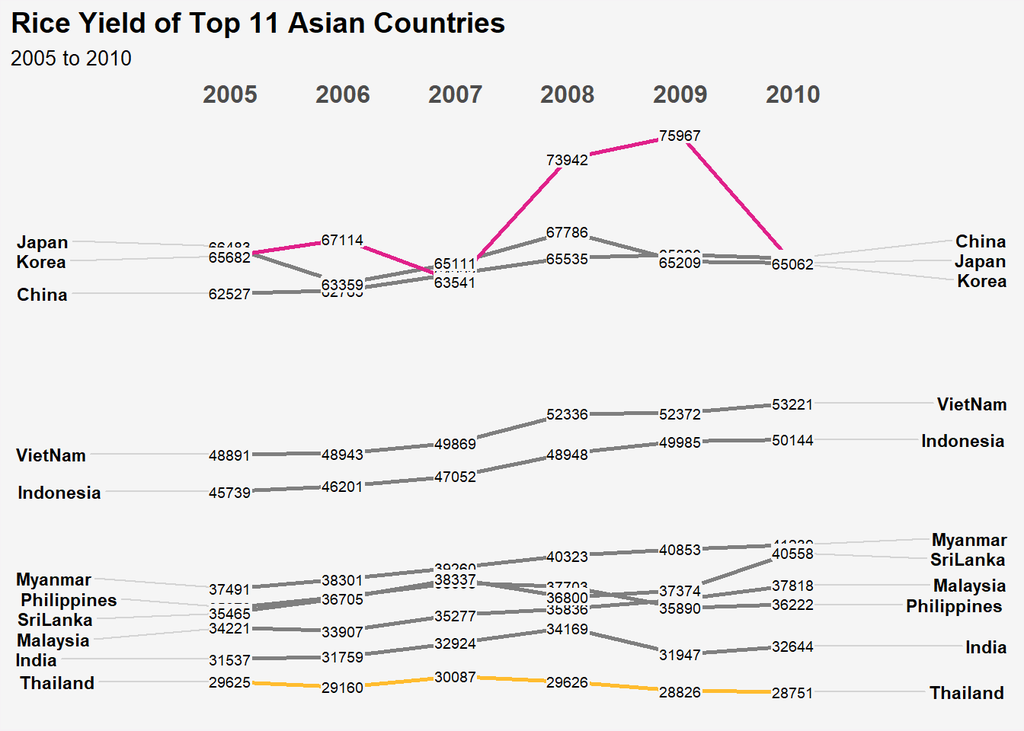

```r
rice %>%
  mutate(Year = factor(Year)) %>%
  filter(Year %in% c(2005, 2006, 2007, 2008, 2009, 2010)) %>%
  newggslopegraph(Year, Yield, Country,
                Title = "Rice Yield of Top 11 Asian Countries",
                SubTitle = "2005 to 2010",
                Caption = NULL,
                LineColor = c("Korea" = "#e0218a", "Thailand" = "#FFBC2F"),
                DataLabelFillColor = "#f5f5f5",) +
    theme(
        plot.background = element_rect(fill = "#f5f5f5", color = "#f5f2f5"),
        panel.background = element_rect(fill="#f5f5f5")
      )
```

## 6 BumpCharts in R

Another popular visualisation is the bump chart, which is a type of line chart which shows changes in rankings over time.

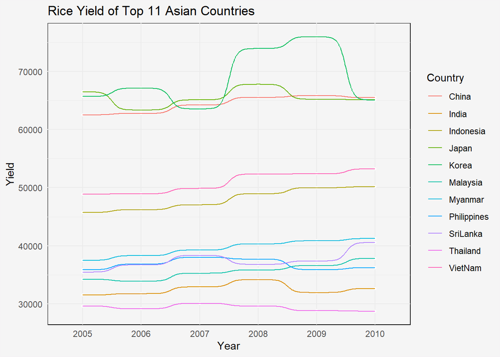

```r
rice %>%
  mutate(Year = factor(Year)) %>%
  filter(Year %in% c(2005, 2006, 2007, 2008, 2009, 2010)) %>%
  ggplot(aes(x = Year,
         y = Yield,
         color = Country))+
  geom_point(color = "#FFFFFF", size = 1) +
  ggbump::geom_bump(mapping=aes(x = Year,
                                y = Yield,
                                group = Country
                                ))+
  labs(title = "Rice Yield of Top 11 Asian Countries") +
  theme_minimal()+
  theme(
        plot.background = element_rect(fill = "#f5f5f5", color = "#f5f2f5"),
        panel.background = element_rect(fill="#f5f5f5"))
```